# Project3

```python
import pandas as pd
import matplotlib.pyplot as plt
import matplotlib.patches as mpatches
import numpy as np
from sklearn.datasets import load_wine
from sklearn.linear_model import LinearRegression
from sklearn.discriminant_analysis import LinearDiscriminantAnalysis
from sklearn import svm
from sklearn.model_selection import train_test_split
from sklearn.metrics import confusion_matrix
from sklearn.metrics import classification_report
import statsmodels.api as sm
data = pd.read_csv("./mirror/gap.tsv", sep="\t")
#print(data.to_string())
```

Exercise 1

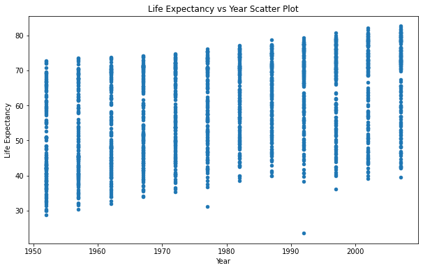

```python
ax = data.plot(x='year', y='lifeExp', kind='scatter', figsize=(10, 6))
ax.set_xlabel("Year")
ax.set_ylabel("Life Expectancy")
ax.set_title("Life Expectancy vs Year Scatter Plot")
plt.show()
```

```python
years = data.year.unique()
row = 0
col = 0
total_year = len(years)
total_country = len(data.country.unique())
#2D list of life expectancy over year
life_exp_per_year = [[0]*total_country for rows in range(total_year)]

while row < len(data.lifeExp):
    for i in range(total_year):
        life_exp_per_year[i][col] = data['lifeExp'][col*len(years)+i]
    row += total_year
    col += 1
```

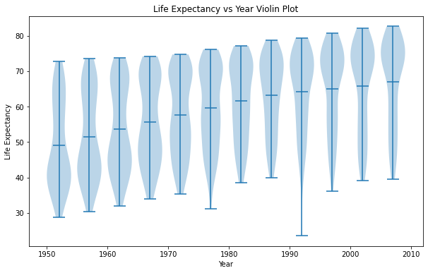

```python
fig, ax = plt.subplots(figsize=(10, 6))
ax.violinplot(life_exp_per_year, years, widths=4, showmeans=True)
ax.set_xlabel("Year")
ax.set_ylabel("Life Expectancy")
ax.set_title("Life Expectancy vs Year Violin Plot")
plt.show()
```

Question 1: The general trend for life expectancy across time is increasing based on the scatter plot and violin plot created above and it seems that the trend is linear.

Question 2: According to the violin plot, it looks like the distribution is bottom skewed over time, meaning that life expectancy across countries is increasing, and the plot is going from bimodal to unimodal. If considering mean value as the center, the distribution is not symmetric around its center.

Question 3: I might reject the null hypothesis of no relationship. Since life expectancy can be affected by various factors, which the most obvious one is the advancement of medical technology, there should be some sort of relationship between life expectancy and year. Also, the plots above show that life expectancy is increasing over time.

Question 4: Since residual is the differences between observed and predicted values (regression line) of data and the distribution of the life expectancy data won’t change, the violin plot of residuals vs year and the linear model from Q3 will look pretty much the same.

Question 5: If there is a linear relationship between life expectancy and year, then we can say that there are dense plot points around the regression line. Therefore, the violin plots should look unimodal and and symmetric around the predicted values.

Exercise 2

```
Intercept: -585.6521874415448
Slope: 0.3259038276371518
```

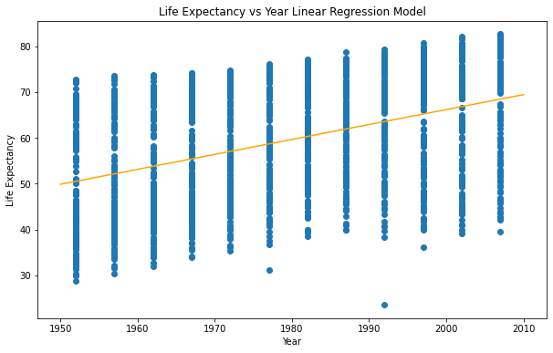

```python
x = data['year'].values.reshape(-1, 1)
y = data['lifeExp'].values.reshape(-1, 1)
model = LinearRegression(fit_intercept=True).fit(x, y)

x_train = np.linspace(1950, 2010).reshape(-1, 1)
y_train = model.predict(x_train)
intercept = model.intercept_[0]
slope = model.coef_[0][0]
print("Intercept:", intercept)
print("Slope:", slope)

plt.figure(figsize=(10, 6))
plt.scatter(x, y)
plt.plot(x_train, y_train, color='orange')
plt.xlabel("Year")
plt.ylabel("Life Expectancy")
plt.title("Life Expectancy vs Year Linear Regression Model")
plt.show()
```

Question 6: Based on the co-efficient of the linear regression model, life expectancy increases by 0.325904 every year around the world.

Question 7: I reject the null hypothesis of no relationship between year and life expectancy. According to the plot in exercise 2, the slope of the line is positive, showing that the two variables are positively related.

Exercise 3

```python
data['residual'] = data['lifeExp']- (intercept + data['year']*slope)
row = 0
col = 0
residual_per_year = [[0]*total_country for rows in range(total_year)]

while row < len(data.residual):
    for i in range(total_year):
        residual_per_year[i][col] = data['residual'][col*len(years)+i]
    row += total_year
    col += 1
```

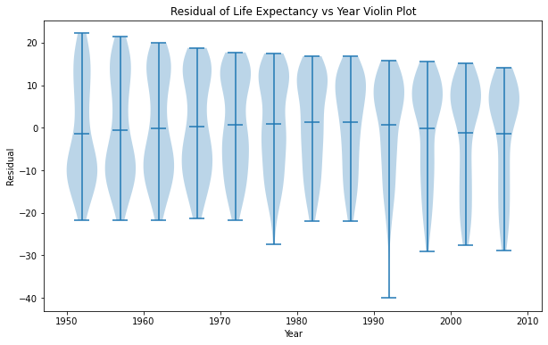

```python
fig, ax = plt.subplots(figsize=(10, 6))
ax.violinplot(residual_per_year, years, widths=4, showmeans=True)
ax.set_xlabel("Year")
ax.set_ylabel("Residual")
ax.set_title("Residual of Life Expectancy vs Year Violin Plot")
plt.show()
```

Question 8: The residuals vs year plot match my expectation from Q4 since the probability of life expectancy will not change between two plots.

```python
#List of continents
continents = []
#2D list of residual over continent
residual_per_continent = []
continent_group = data.groupby(['continent'])

for name, group in continent_group:
    continents.append(group.iloc[0][1])
    residual_per_continent.append(group.residual)
```

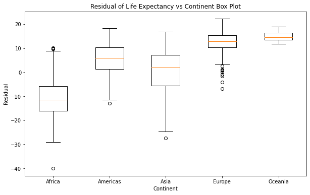

```python
fig, ax = plt.subplots(figsize=(10, 6))
ax.boxplot(residual_per_continent, labels=continents, showbox=True)
ax.set_xlabel("Continent")
ax.set_ylabel("Residual")
ax.set_title("Residual of Life Expectancy vs Continent Box Plot")
plt.show()
```

Question 9: It looks like Africa has the lowest average life expectancy and Oceania has the highest average life expectancy across time. If making a linear model of life expectancy vs year for each continent, we can figure out their trend of life expectancy over time, and calculate the increasing or decreasing amount related to each continent.

Exercise 5

```
Africa regression line slope: 0.2895292630446486
```

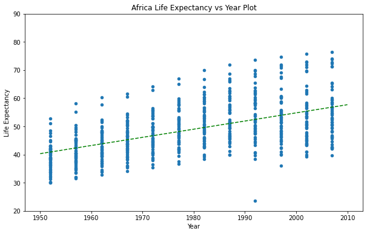

```
Americas regression line slope: 0.3676509370629368
```

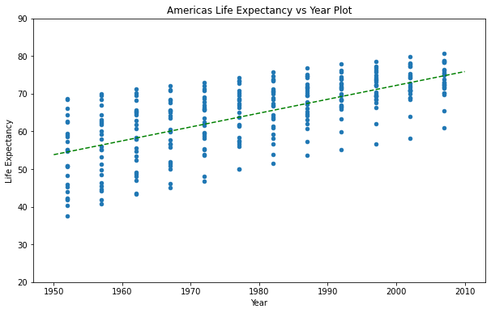

```
Asia regression line slope: 0.45312240389913017
```

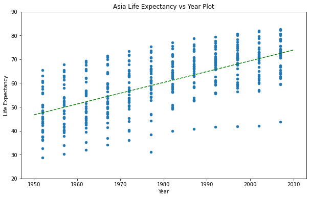

```
Europe regression line slope: 0.22193214452214455
```

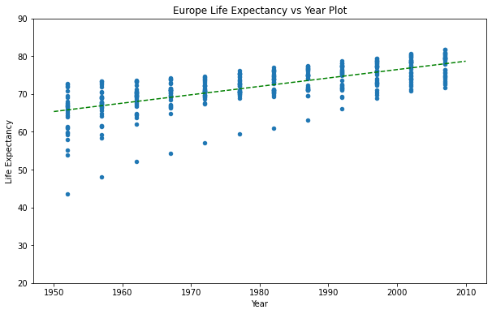

```
Oceania regression line slope: 0.2102723776223778
```

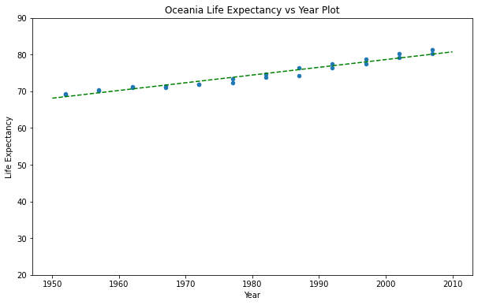

```python
for name, group in continent_group:
    ax = group.plot(x='year', y='lifeExp', kind='scatter', xlabel=("Year"), ylabel=("Life Expectancy"), figsize=(10, 6))
    ax.set_title("{} Life Expectancy vs Year Plot".format(group.iloc[0][1]))
    ax.set_ylim(20,90)

    #Create linear regression line for each plot
    trend = np.polyfit(group['year'], group['lifeExp'], 1)
    print("{} regression line slope: {} ".format(group.iloc[0][1], trend[0]))
    poly = np.poly1d(trend)
    x = np.linspace(1950, 2010)
    y = poly(x)
    plt.plot(x, y, 'g--')
    plt.show()
```

Question 10: Yes, the model should include the interaction term for continent and year because the slope of the regression line model for each plot is different. While Asia has the largerst slope value, meaning that the line is steepest among all continents, Oceania has a relatively flat regression line. Once we make the continent vs year plot, we will have a better understanding about life expectancy trend across continents over time.

Exercise 6: To include a term for an interaction between continent and year, I group the data by continent and year, calculate the average life expectancy value per year for each continent and fit data into a linear regression model.

```python
mean_group = data.groupby(['continent', 'year'])
#2D list of mean life expectancy over year
mean_life_exp_per_year = []
mean_year_group = []

for name, group in mean_group:
    mean = group.lifeExp.sum()/len(group)
    mean_life_exp_per_year.append(mean)
    mean_year_group.append(group.iloc[0][2])
```

```
Intercept: -546.7147983489473
Slope: 0.30850142523024765
```

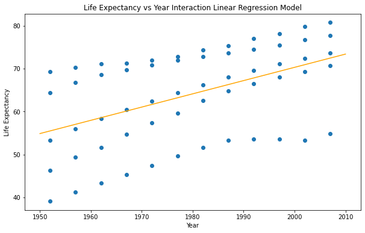

```python
mean_year_group = np.reshape(mean_year_group, (-1, 1))
model = LinearRegression(fit_intercept=True)
model.fit(mean_year_group, mean_life_exp_per_year)

x_train = np.linspace(1950, 2010).reshape(-1, 1)
y_train = model.predict(x_train)
intercept = model.intercept_
slope = model.coef_[0]
print("Intercept:", intercept)
print("Slope:", slope)

plt.figure(figsize=(10, 6))
plt.scatter(mean_year_group, mean_life_exp_per_year)
plt.plot(x_train, y_train, color='orange')
plt.xlabel("Year")
plt.ylabel("Life Expectancy")
plt.title("Life Expectancy vs Year Interaction Linear Regression Model")
plt.show()
```

```python
mean_year_group = sm.add_constant(mean_year_group)
model = sm.OLS(mean_life_exp_per_year, mean_year_group).fit()
print(model.summary())
```

```
                            OLS Regression Results
==============================================================================
Dep. Variable:                      y   R-squared:                       0.248
Model:                            OLS   Adj. R-squared:                  0.235
Method:                 Least Squares   F-statistic:                     19.08
Date:                Wed, 27 Apr 2022   Prob (F-statistic):           5.24e-05
Time:                        03:07:46   Log-Likelihood:                -218.83
No. Observations:                  60   AIC:                             441.7
Df Residuals:                      58   BIC:                             445.8
Df Model:                           1
Covariance Type:            nonrobust
==============================================================================
                 coef    std err          t      P>|t|      [0.025      0.975]
------------------------------------------------------------------------------
const       -546.7148    139.797     -3.911      0.000    -826.549    -266.881
x1             0.3085      0.071      4.368      0.000       0.167       0.450
==============================================================================
Omnibus:                        8.863   Durbin-Watson:                   0.109
Prob(Omnibus):                  0.012   Jarque-Bera (JB):                4.702
Skew:                          -0.481   Prob(JB):                       0.0953
Kurtosis:                       2.023   Cond. No.                     2.27e+05
==============================================================================

Notes:
[1] Standard Errors assume that the covariance matrix of the errors is correctly specified.
[2] The condition number is large, 2.27e+05. This might indicate that there are
strong multicollinearity or other numerical problems.
```

Question 12: The code is included in Exercise 5.

1. Africa: 0.28953
2. Americas: 0.36765
3. Asia: 0.45312
4. Europe: 0.22193
5. Oceania: 0.21027

Exercise 7: Since the predicted life expectancy values on the linear regression line have the residual value of zero, and the range of positive residual values is decreasing over time, meaning that predicted y-axis values are increasing and the regression line has positive slope. Therefore, the violin plot of the interaction model matches the linear regression model pretty well.

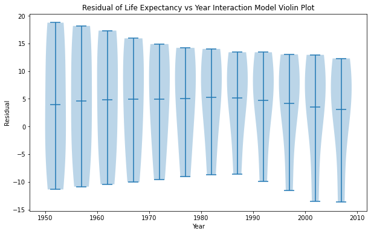

```python
mean_residual_per_year = [[0]*len(continents) for x in range(total_year)]
row = 0
col = 0

for name, group in mean_group:
    mean = group.residual.sum()/len(group)
    mean_residual_per_year[row][col] = mean
    row += 1
    if row == total_year:
        row = 0
        col += 1

fig, ax = plt.subplots(figsize=(10, 6))
ax.violinplot(mean_residual_per_year, years, widths=4, showmeans=True)
ax.set_xlabel("Year")
ax.set_ylabel("Residual")
ax.set_title("Residual of Life Expectancy vs Year Interaction Model Violin Plot")
plt.show()
```

Part 2 (I didn't apply holdout validation when created plots for this part)

```python
#test = load_wine(return_X_y=True, as_frame=True)
#print(test[0])
```

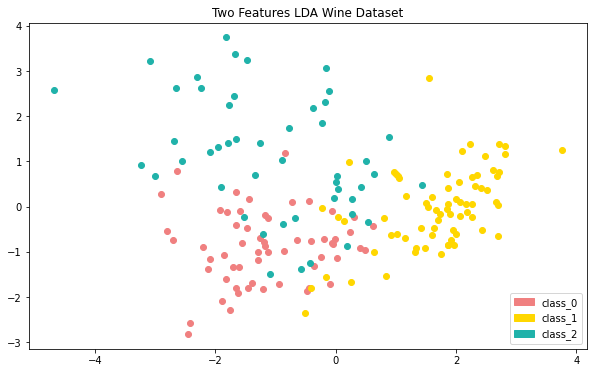

```python
wine_data = load_wine()
lda_two_features_model = LinearDiscriminantAnalysis()
lda_two_features_model = lda_two_features_model.fit_transform(wine_data.data[:, (0,9)], wine_data.target)

colors = ["lightcoral", "gold", "lightseagreen"]
plt.figure(figsize=(10, 6))
for i in range (len(lda_two_features_model)):
    plt.scatter(lda_two_features_model[i, 0], lda_two_features_model[i, 1], color=colors[wine_data.target[i]])

plt.title("Two Features LDA Wine Dataset")
handles = [mpatches.Patch(color=color, label=label) for label, color in [('class_0', colors[0]), ('class_1', colors[1]), ('class_2', colors[2])]]
plt.legend(handles=handles, loc="lower right", frameon=True)
plt.show()
```

```python
#Get two features from the wine dataset (alcohol and color_intensity columns) and run the Linear SVM algorithm
attributes = wine_data.data[:, (9, 0)]
svm_two_features_model = svm.SVC(kernel="linear")
svm_two_features_model = svm_two_features_model.fit(attributes, wine_data.target)
classes = svm_two_features_model.classes_

#test if the model works as expected
#print(svm_model.predict(np.reshape([14.16, 9.700000], (1, -1))))

#create seperating hyperplanes for each class
a=[]
for i in classes:
    a.append(-svm_two_features_model.coef_[i, 0]/svm_two_features_model.coef_[i, 1])

x_predict = np.linspace(0, 13.5)
y_predict = []
for i in classes:
    y_predict.append(a[i] * x_predict - svm_two_features_model.intercept_[i]/svm_two_features_model.coef_[i, 1])
```

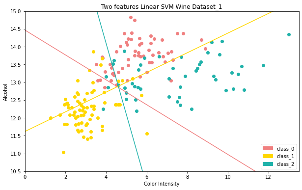

```python
colors = ["lightcoral", "gold", "lightseagreen"]
fig, ax1 = plt.subplots(figsize=(10, 6))

#Plot Color Intensity vs Alcohol data
for i in range (len(wine_data.data)):
    ax1.scatter(attributes[i, 0], attributes[i, 1], color=colors[wine_data.target[i]])

#Plot seperating hyperplanes
for i in classes:
    ax1.plot(x_predict, y_predict[i], color=colors[i])

ax1.set_title("Two features Linear SVM Wine Dataset_1")
ax1.set_xlim(0, 13.5)
ax1.set_ylim(10.5, 15)
ax1.set_xlabel("Color Intensity")
ax1.set_ylabel("Alcohol")
handles = [mpatches.Patch(color=color, label=label) for label, color in [('class_0', colors[0]), ('class_1', colors[1]), ('class_2', colors[2])]]
ax1.legend(handles=handles, loc="lower right", frameon=True)
plt.show()
```

```python
#Another way to visualize the classifier in a Linear SVM model
x_min = wine_data.data[:, 9].min()-1
x_max = wine_data.data[:, 9].max()+1
y_min = wine_data.data[:, 0].min()-1
y_max = wine_data.data[:, 0].max()+1

x_grid, y_grid = np.meshgrid(np.arange(x_min, x_max, 0.01), np.arange(y_min, y_max, 0.01))
z = svm_two_features_model.predict(np.c_[x_grid.ravel(), y_grid.ravel()])
#Transform to a 581 * 1372 array
z = z.reshape(x_grid.shape)
```

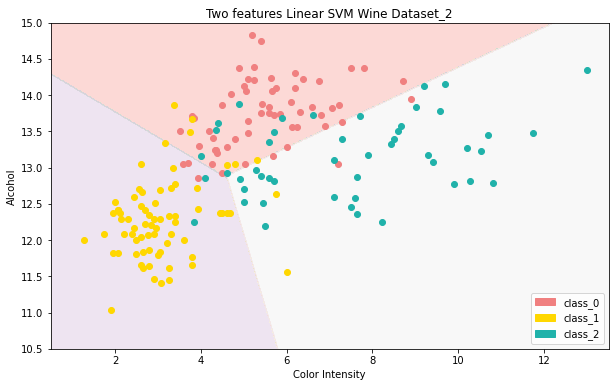

```python
colors = ["lightcoral", "gold", "lightseagreen"]
fig, ax2 = plt.subplots(figsize=(10, 6))
#Use plt.contour to show the seperating hyperplanes
ax2.contourf(x_grid, y_grid, z, cmap=plt.cm.Pastel1, alpha=0.5)

for i in range (len(wine_data.data)):
    ax2.scatter(attributes[i, 0], attributes[i, 1], color=colors[wine_data.target[i]])

ax2.set_title("Two features Linear SVM Wine Dataset_2")
ax2.set_xlim(0.5, 13.5)
ax2.set_ylim(10.5, 15)
ax2.set_xlabel("Color Intensity")
ax2.set_ylabel("Alcohol")
handles = [mpatches.Patch(color=color, label=label) for label, color in [('class_0', colors[0]), ('class_1', colors[1]), ('class_2', colors[2])]]
ax2.legend(handles=handles, loc="lower right", frameon=True)
plt.show()
```

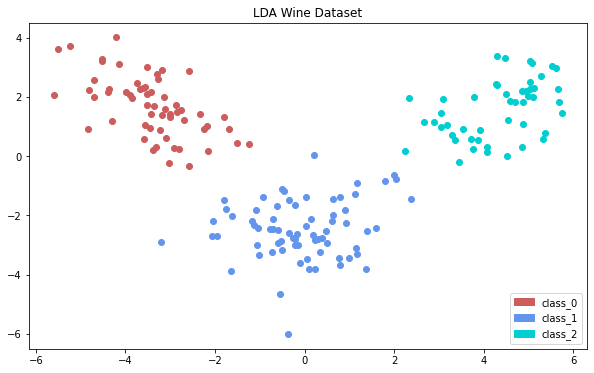

```python
#Reduce the dimension of attributes by LDA and run the Linear SVM algorithm
lda_model = LinearDiscriminantAnalysis()
lda_model = lda_model.fit_transform(wine_data.data, wine_data.target)

colors = ["indianred", "cornflowerblue", "darkturquoise"]
plt.figure(figsize=(10, 6))
for i in range (len(lda_model)):
    plt.scatter(lda_model[i, 0], lda_model[i, 1], color=colors[wine_data.target[i]])

plt.title("LDA Wine Dataset")
handles = [mpatches.Patch(color=color, label=label) for label, color in [('class_0', colors[0]), ('class_1', colors[1]), ('class_2', colors[2])]]
plt.legend(handles=handles, loc="lower right", frameon=True)
plt.show()
```

```python
svm_model = svm.SVC(kernel="linear")
svm_model = svm_model.fit(lda_model, wine_data.target)
classes = svm_model.classes_

x_min = lda_model[:, 0].min()-1
x_max = lda_model[:, 0].max()+1
y_min = lda_model[:, 1].min()-1
y_max = lda_model[:, 1].max()+1

x_grid, y_grid = np.meshgrid(np.arange(x_min, x_max, 0.01), np.arange(y_min, y_max, 0.01))
z = svm_model.predict(np.c_[x_grid.ravel(), y_grid.ravel()])
#Transform to a 1201 * 1334 array
z = z.reshape(x_grid.shape)
```

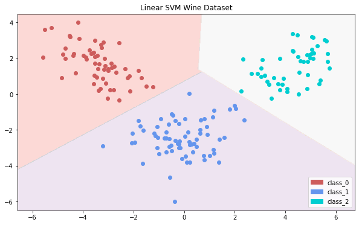

```python
#Visualize the classifier in a Linear SVM model
colors = ["indianred", "cornflowerblue", "darkturquoise"]
plt.figure(figsize=(10, 6))
plt.contourf(x_grid, y_grid, z, cmap=plt.cm.Pastel1, alpha=0.5)
for i in range (len(lda_model)):
    plt.scatter(lda_model[i, 0], lda_model[i, 1], color=colors[wine_data.target[i]])

plt.ylim(-6.5, 4.5)
plt.title("Linear SVM Wine Dataset")
handles = [mpatches.Patch(color=color, label=label) for label, color in [('class_0', colors[0]), ('class_1', colors[1]), ('class_2', colors[2])]]
plt.legend(handles=handles, loc="lower right", frameon=True)
plt.show()
```

The wine dataset I used is provided by SKLearn, it includes three classes (class_0, class_1 and class_2) and 13 different attribites for each class. I tried to predict the class that a wine belongs to based on its attribute values. For the first two prediction models, I only considered two features from the dataset, which are alcohol and color intensity. On the other hand, all features are considered in the third and fourth model.

Since there are three different classes for this dataset, it makes more sense to pick classifiers to predict the performance. The two algorithms I chose to train the dataset are Linear Discriminant Analysis and Linear SVM. To get a better sense on how the data points spread on a 2d graph, I trained the data with only two features first. Based on the first plot, it looks like the LDA model with two features do fairly well outside the domain (-1, 1) and range(-2, 1). For the linear SVM model with two features, the hyperplanes seperate each class's data points quite well, along with some ambiguity at domain (4, 6) and range (12.5, 13.5).

After testing out the models with two features, I used LDA for dimensionality reduction since it becomes more difficult to visualize high dimensional data (13 dimensions in this case). The data is transformed after running the LDA fit method and it can be visualized by creating the scatter plot. According to the LDA plot, we can find out that the model did a good job on identifying data points by class type. I selected Linear SVM because it seems that the clusters can be well seperated by lines according to the LDA plot. The last plot shows that the Linear SVM model works well on the dataset, which the dataset's dimension has been reducted by LDA.

```python
#Apply holdout validation
X_train, X_test, y_train, y_test = train_test_split(wine_data.data, wine_data.target, test_size=0.4, random_state=0)
lda_model = LinearDiscriminantAnalysis()
lda_model = lda_model.fit(X_train, y_train)
lda_predict = lda_model.predict(X_test)

svm_model = svm.SVC(kernel="linear")
svm_model = svm_model.fit(X_train, y_train)
svm_predict = svm_model.predict(X_test)

classes = ['class_0', 'class_1', 'class_2']
#matrix_lda = confusion_matrix(lda_predict, y_test)
#matrix_svm = confusion_matrix(svm_predict, y_test)

print("LDA performance metric")
print(classification_report(y_test, lda_predict, target_names = classes) + "\n")
print("Linear SVM performance metric")
print(classification_report(y_test, svm_predict, target_names = classes))
```

```
LDA performance metric
              precision    recall  f1-score   support

     class_0       0.96      1.00      0.98        22
     class_1       1.00      0.94      0.97        31
     class_2       0.95      1.00      0.97        19

    accuracy                           0.97        72
   macro avg       0.97      0.98      0.97        72
weighted avg       0.97      0.97      0.97        72


Linear SVM performance metric
              precision    recall  f1-score   support

     class_0       1.00      1.00      1.00        22
     class_1       1.00      0.90      0.95        31
     class_2       0.86      1.00      0.93        19

    accuracy                           0.96        72
   macro avg       0.95      0.97      0.96        72
weighted avg       0.96      0.96      0.96        72
```

For the accuracy of positive predictions, i.e., precision, LDA does way better than SVM on class_2, SVM does slightly better than LDA on class_0 and both models did perfect on class_1.

For the ability to find all positive instances, i.e., recall, they both did perfect on identifying the positives of class_0 and class_2, while LDA did slightly better on class_1.

According to the definition of f1-score, "the closer the value of the f1-score is to 1.0, the better the expected performance of the model is". The LDA model performed quite well on all three classes, while SVM performed better on class_0 and class_1 compare to class_2.